# Homework 06

Author

cgao19

Published

October 4, 2026

All work is in Python. The single training/test split is drawn with seed **432** and shared by both questions. Neighbor weights are equal throughout, and plot formatting is left at library defaults.

**Show the workflow**

```python
import numpy as np
import pandas as pd
import matplotlib.pyplot as plt
from sklearn.linear_model import LogisticRegression
from sklearn.neighbors import KNeighborsClassifier
from sklearn.metrics import roc_curve, roc_auc_score

pd.set_option("display.float_format", lambda v: f"{v:.4f}")
```

## Question 1: Compare KNN and logistic regression

The 569 rows are permuted once and the first $\operatorname{round}(0.7 \cdot 569) = 398$ go to training, leaving 171 for testing. Each predictor is centered by its training mean and divided by its training standard deviation (divisor $n-1$); the test rows reuse those same constants, so no test information enters the fitted models.

**Show the workflow**

```python
SEED = 432
rng = np.random.default_rng(SEED)

data = pd.read_csv("data/breast-cancer.csv")
predictors = ["mean_radius", "mean_texture", "mean_smoothness"]
X = data[predictors].to_numpy()
y = data["y"].to_numpy()

idx = rng.permutation(len(y))
n_train = round(0.7 * len(y))
train, test = idx[:n_train], idx[n_train:]

center = X[train].mean(axis=0)
scale = X[train].std(axis=0, ddof=1)
X_train, X_test = (X[train] - center) / scale, (X[test] - center) / scale
y_train, y_test = y[train], y[test]

pd.DataFrame(
    {"n": [len(y_train), len(y_test)],
     "malignant": [y_train.sum(), y_test.sum()],
     "malignant rate": [y_train.mean(), y_test.mean()]},
    index=["training", "test"],
)
```

|  | n | malignant | malignant rate |
| --- | --- | --- | --- |
| training | 398 | 154 | 0.3869 |
| test | 171 | 58 | 0.3392 |

Logistic regression is fit with `penalty="none"` (scikit-learn 1.0), so it is the ordinary maximum-likelihood fit with an intercept. For KNN, `predict_proba` returns the fraction of the $k$ nearest training points that are malignant, which is the estimate of $P(Y=1 \mid X=x)$.

**Show the workflow**

```python
ks_q1 = [5, 15, 25, 35, 45]

models = {"logistic": LogisticRegression(penalty="none").fit(X_train, y_train)}
for k in ks_q1:
    models[f"KNN, k = {k}"] = KNeighborsClassifier(n_neighbors=k).fit(X_train, y_train)

test_prob = {name: m.predict_proba(X_test)[:, 1] for name, m in models.items()}
auc_q1 = pd.Series({name: roc_auc_score(y_test, p) for name, p in test_prob.items()},
                   name="test AUC")
auc_q1.to_frame()
```

|  | test AUC |
| --- | --- |
| logistic | 0.9820 |
| KNN, k = 5 | 0.9596 |
| KNN, k = 15 | 0.9789 |
| KNN, k = 25 | 0.9755 |
| KNN, k = 35 | 0.9778 |
| KNN, k = 45 | 0.9772 |

**Show the workflow**

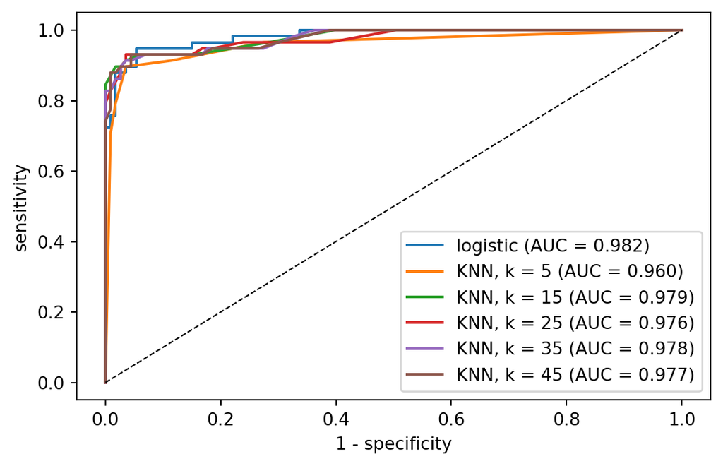

Test ROC curves for logistic regression and five KNN fits.

```python
fig, ax = plt.subplots()
for name, p in test_prob.items():
    fpr, tpr, _ = roc_curve(y_test, p)
    ax.plot(fpr, tpr, label=f"{name} (AUC = {auc_q1[name]:.3f})")
ax.plot([0, 1], [0, 1], "k--", lw=0.8)
ax.set_xlabel("1 - specificity")
ax.set_ylabel("sensitivity")
ax.legend()
plt.show()
```

**Preferred model: logistic regression.** It has the largest test AUC, 0.982, so it ranks a malignant case above a benign one about 98% of the time. The best KNN fit is $k=15$ at 0.979. The KNN curves improve sharply from $k=5$ (0.960), whose estimated probabilities take only six values and are noisy, and then stay flat between 0.976 and 0.979 for $k$ from 15 to 45. The gap between logistic regression and the best KNN is small for a test set with only 58 malignant cases, so the AUC alone does not separate them decisively. But logistic regression is at least as good, it needs no tuning of $k$, and with three predictors a linear log-odds boundary is evidently flexible enough here. Its coefficients also show which measurements push the probability up. KNN offers no advantage in this case to make up for being harder to interpret.

## Question 2: Training and test ROC curves

The split and standardization are those of Question 1. Calling `predict_proba` on the training matrix itself makes each training point its own nearest neighbor at distance zero, which is the self-inclusion the question asks for. No two rows share all three predictor values, so for $k=1$ every training point’s only neighbor is itself.

**Show the workflow**

```python
ks_q2 = [1, 3, 5, 10, 20]

prob_q2, auc_rows = {}, {}
for k in ks_q2:
    knn = KNeighborsClassifier(n_neighbors=k).fit(X_train, y_train)
    prob_q2[k] = {"training": (y_train, knn.predict_proba(X_train)[:, 1]),
                  "test": (y_test, knn.predict_proba(X_test)[:, 1])}
    auc_rows[k] = {s: roc_auc_score(*prob_q2[k][s]) for s in ("training", "test")}

auc_q2 = pd.DataFrame(auc_rows).T.rename_axis("k")
auc_q2["training - test"] = auc_q2["training"] - auc_q2["test"]
auc_q2
```

| k | training | test | training - test |
| --- | --- | --- | --- |
| 1 | 1.0000 | 0.8523 | 0.1477 |
| 3 | 0.9903 | 0.9310 | 0.0594 |
| 5 | 0.9859 | 0.9596 | 0.0263 |
| 10 | 0.9776 | 0.9706 | 0.0069 |
| 20 | 0.9786 | 0.9777 | 0.0009 |

**Show the workflow**

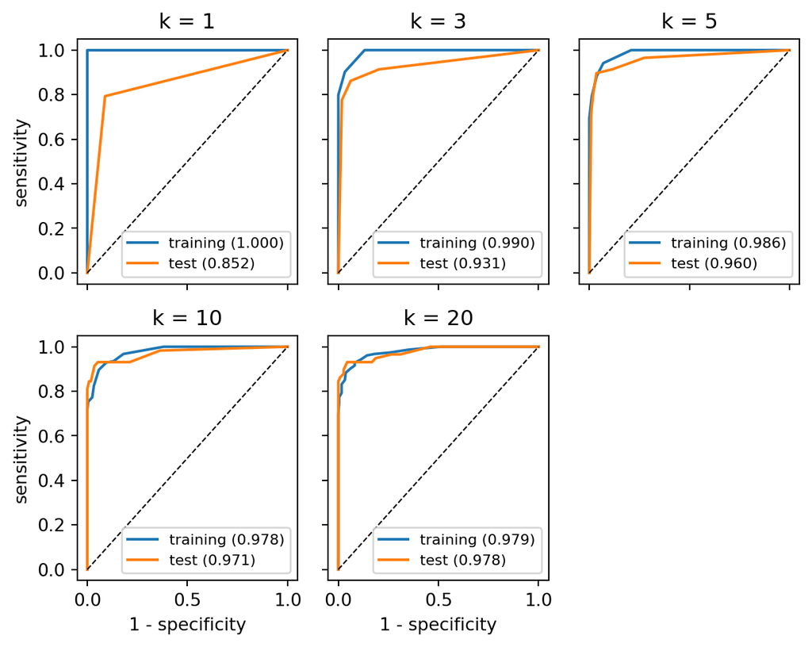

Training and test ROC curves for KNN, one panel per k.

```python
fig, axes = plt.subplots(2, 3, figsize=(6.5, 5.2), sharex=True, sharey=True)
for ax, k in zip(axes.flat, ks_q2):
    for s in ("training", "test"):
        fpr, tpr, _ = roc_curve(*prob_q2[k][s])
        ax.plot(fpr, tpr, label=f"{s} ({auc_q2.loc[k, s]:.3f})")
    ax.plot([0, 1], [0, 1], "k--", lw=0.8)
    ax.set_title(f"k = {k}")
    ax.legend(fontsize="small", loc="lower right")
axes.flat[-1].axis("off")
for ax in axes[1]:
    ax.set_xlabel("1 - specificity")
for ax in axes[:, 0]:
    ax.set_ylabel("sensitivity")
fig.tight_layout()
plt.show()
```

**What the gap shows.** Training AUC is always above test AUC, and the gap shrinks quickly as $k$ grows: 0.148 at $k=1$, 0.059 at $k=3$, 0.026 at $k=5$, and nearly zero by $k=20$. Test AUC moves the other way, rising from 0.852 to 0.978. The reason is that a training point’s own label is one of the $k$ labels averaged into its estimate. That label carries weight $1/k$, so the estimate leans toward the right answer by construction, and this advantage disappears for a new point, which is never among its own neighbors. A large $k$ dilutes the self-vote, so training and test estimates come from essentially the same averaging and the two AUCs meet. For $k$ between 10 and 20, training AUC no longer decreases.

**At $k=1$.** Each training point’s estimate is its own label, exactly 0 or 1. So every malignant case is ranked above every benign one, and the training ROC curve jumps straight to the upper-left corner with AUC exactly 1. This only says that the model has memorized the training labels; the response itself was used to make each prediction. A test point instead takes the label of one nearby training point. That estimate is also 0 or 1, so the test ROC curve has a single interior corner (sensitivity and specificity at the cutoff 0.5) joined by straight lines, and the AUC drops to 0.852. One neighbor gives the noisiest possible estimate of $p(x)$. Training performance therefore cannot be used to judge or tune $k$: by that measure $k=1$ would look best, when it is in fact the worst of the five on new data.

## Question 3: Peer evaluation of Homework 5

Peer-review issue: https://github.com/rruiz35/stat432-fall2026/issues/2

### Part 1: Identify the item for improvement

I selected the Homework 5 report in the repository `rruiz35/stat432-fall2026` (`homework/week-05/homework-05.html`), **Question 4(c)**: the Python code that displays the three test images misclassified by Euclidean 5NN. The item for improvement is the grayscale display range passed to `plt.imshow`.

### Part 3: Correction

The correction keeps the report’s classifier, its choice of the first three Euclidean errors, and the title format, and changes only the display range to `vmin=-1, vmax=1`. The pixel files are the Homework 5 course copies.

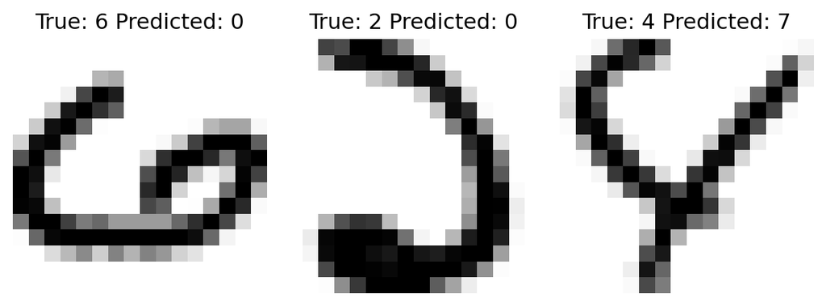

Revised display of the first three Euclidean 5NN errors, with vmin=-1 and vmax=1.

```python
zip_train = np.loadtxt("../week-05/data/knn/zip-train.csv.gz", delimiter=",")
zip_test = np.loadtxt("../week-05/data/knn/zip-test.csv.gz", delimiter=",")
X5, y5 = zip_train[:1000, 1:], zip_train[:1000, 0].astype(int)
X5_test, y5_test = zip_test[:500, 1:], zip_test[:500, 0].astype(int)

y5_hat = np.zeros(len(y5_test), dtype=int)
for i in range(len(y5_test)):
    d = np.sqrt(np.sum((X5 - X5_test[i]) ** 2, axis=1))
    neighbors = np.argsort(d, kind="stable")[:5]
    y5_hat[i] = np.argmax(np.bincount(y5[neighbors], minlength=10))

incorrect = np.flatnonzero(y5_hat != y5_test)[:3]
plt.figure(figsize=(6.5, 2.4))
for l, i in enumerate(incorrect):
    plt.subplot(1, 3, l + 1)
    plt.imshow(zip_test[i, 1:].reshape(16, 16), cmap="gray_r",
               vmin=-1, vmax=1, interpolation="nearest")
    plt.title(f"True: {y5_test[i]} Predicted: {y5_hat[i]}")
    plt.axis("off")
plt.tight_layout()
plt.show()
```

The three images are again test rows 4, 13, and 14 (true 6, 2, 4; predicted 0, 0, 7), so the report’s written comments on these digits still apply. In the revised GitHub Issue I asked the author to set `vmin=-1, vmax=1`, regenerate the figure for the same three images, keep the true and predicted labels in the titles, and replace the figure in the report.